# Red Wine Quality by Chelsey De Dios

We will be exploring data regarding qualities of nearly 1600 red wines. This dataset includes a variety of objective observations on red wine and a rating of the wines based on analysis by a group of wine experts. I chose this dataset as I used to be a server at a high end restaurant and I would be interested to know if the conventional knowledge that we were taught to help customers is true within this dataset.

# Univariate Plots Section

## Statistical Summary

```
##        X          fixed.acidity   volatile.acidity  citric.acid
##  Min.   :   1.0   Min.   : 4.60   Min.   :0.1200   Min.   :0.000
##  1st Qu.: 400.5   1st Qu.: 7.10   1st Qu.:0.3900   1st Qu.:0.090
##  Median : 800.0   Median : 7.90   Median :0.5200   Median :0.260
##  Mean   : 800.0   Mean   : 8.32   Mean   :0.5278   Mean   :0.271
##  3rd Qu.:1199.5   3rd Qu.: 9.20   3rd Qu.:0.6400   3rd Qu.:0.420
##  Max.   :1599.0   Max.   :15.90   Max.   :1.5800   Max.   :1.000
##  residual.sugar     chlorides       free.sulfur.dioxide total.sulfur.dioxide
##  Min.   : 0.900   Min.   :0.01200   Min.   : 1.00       Min.   :  6.00
##  1st Qu.: 1.900   1st Qu.:0.07000   1st Qu.: 7.00       1st Qu.: 22.00
##  Median : 2.200   Median :0.07900   Median :14.00       Median : 38.00
##  Mean   : 2.539   Mean   :0.08747   Mean   :15.87       Mean   : 46.47
##  3rd Qu.: 2.600   3rd Qu.:0.09000   3rd Qu.:21.00       3rd Qu.: 62.00
##  Max.   :15.500   Max.   :0.61100   Max.   :72.00       Max.   :289.00
##     density             pH          sulphates         alcohol
##  Min.   :0.9901   Min.   :2.740   Min.   :0.3300   Min.   : 8.40
##  1st Qu.:0.9956   1st Qu.:3.210   1st Qu.:0.5500   1st Qu.: 9.50
##  Median :0.9968   Median :3.310   Median :0.6200   Median :10.20
##  Mean   :0.9967   Mean   :3.311   Mean   :0.6581   Mean   :10.42
##  3rd Qu.:0.9978   3rd Qu.:3.400   3rd Qu.:0.7300   3rd Qu.:11.10
##  Max.   :1.0037   Max.   :4.010   Max.   :2.0000   Max.   :14.90
##     quality
##  Min.   :3.000
##  1st Qu.:5.000
##  Median :6.000
##  Mean   :5.636
##  3rd Qu.:6.000
##  Max.   :8.000
```

Here in our statistical summary we see we have mostly objective, measurable observations about the wine, with just quality being a subjective measure of the wines. There are 1599 observations and 13 variables.

## Data Structure

```
## 'data.frame':    1599 obs. of  13 variables:
##  $ X                   : int  1 2 3 4 5 6 7 8 9 10 ...
##  $ fixed.acidity       : num  7.4 7.8 7.8 11.2 7.4 7.4 7.9 7.3 7.8 7.5 ...
##  $ volatile.acidity    : num  0.7 0.88 0.76 0.28 0.7 0.66 0.6 0.65 0.58 0.5 ...
##  $ citric.acid         : num  0 0 0.04 0.56 0 0 0.06 0 0.02 0.36 ...
##  $ residual.sugar      : num  1.9 2.6 2.3 1.9 1.9 1.8 1.6 1.2 2 6.1 ...
##  $ chlorides           : num  0.076 0.098 0.092 0.075 0.076 0.075 0.069 0.065 0.073 0.071 ...
##  $ free.sulfur.dioxide : num  11 25 15 17 11 13 15 15 9 17 ...
##  $ total.sulfur.dioxide: num  34 67 54 60 34 40 59 21 18 102 ...
##  $ density             : num  0.998 0.997 0.997 0.998 0.998 ...
##  $ pH                  : num  3.51 3.2 3.26 3.16 3.51 3.51 3.3 3.39 3.36 3.35 ...
##  $ sulphates           : num  0.56 0.68 0.65 0.58 0.56 0.56 0.46 0.47 0.57 0.8 ...
##  $ alcohol             : num  9.4 9.8 9.8 9.8 9.4 9.4 9.4 10 9.5 10.5 ...
##  $ quality             : int  5 5 5 6 5 5 5 7 7 5 ...
```

Now looking at our data structure we see we are dealing with some very small numbers. Quality is, notably, an integer. This is inconvenient for our purposes because it will cause the graphs to make singular plots. It would be better if quality were treated as a numeric, so let’s change that.

```
## 'data.frame':    1599 obs. of  13 variables:
##  $ X                   : int  1 2 3 4 5 6 7 8 9 10 ...
##  $ fixed.acidity       : num  7.4 7.8 7.8 11.2 7.4 7.4 7.9 7.3 7.8 7.5 ...
##  $ volatile.acidity    : num  0.7 0.88 0.76 0.28 0.7 0.66 0.6 0.65 0.58 0.5 ...
##  $ citric.acid         : num  0 0 0.04 0.56 0 0 0.06 0 0.02 0.36 ...
##  $ residual.sugar      : num  1.9 2.6 2.3 1.9 1.9 1.8 1.6 1.2 2 6.1 ...
##  $ chlorides           : num  0.076 0.098 0.092 0.075 0.076 0.075 0.069 0.065 0.073 0.071 ...
##  $ free.sulfur.dioxide : num  11 25 15 17 11 13 15 15 9 17 ...
##  $ total.sulfur.dioxide: num  34 67 54 60 34 40 59 21 18 102 ...
##  $ density             : num  0.998 0.997 0.997 0.998 0.998 ...
##  $ pH                  : num  3.51 3.2 3.26 3.16 3.51 3.51 3.3 3.39 3.36 3.35 ...
##  $ sulphates           : num  0.56 0.68 0.65 0.58 0.56 0.56 0.46 0.47 0.57 0.8 ...
##  $ alcohol             : num  9.4 9.8 9.8 9.8 9.4 9.4 9.4 10 9.5 10.5 ...
##  $ quality             : num  5 5 5 6 5 5 5 7 7 5 ...
```

## Wine Quality

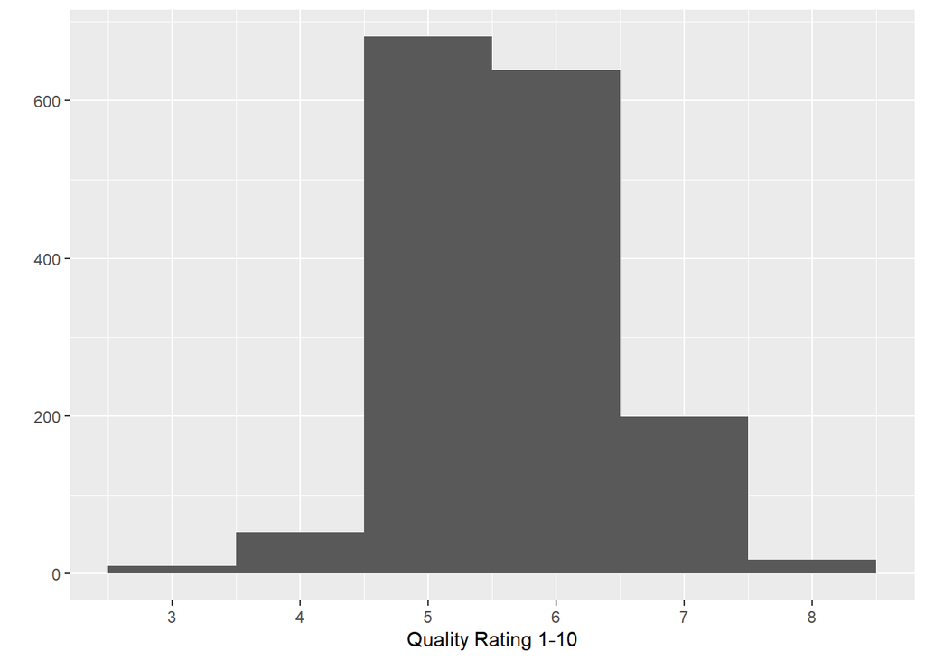

It looks like most of the wine with of middling quality according to our experts with most having a score of 5-6 out of 10. This makes me wonder about how this data was collected, and why so few were rated as exceptionally poor or excellent

## Alcohol Content By Volume

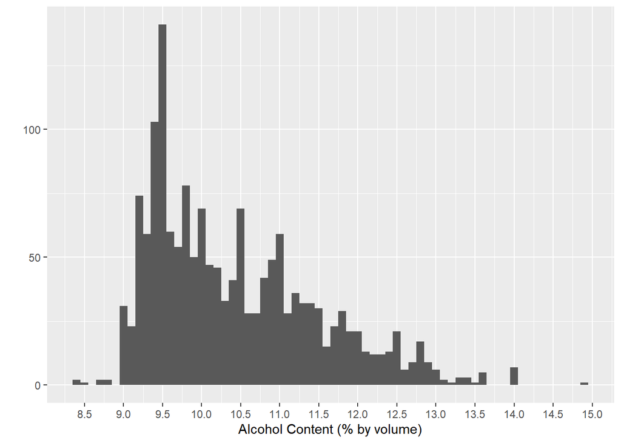

Here we can see that the bulk of our alcohol content is between 9% and 11% by volume with a little bit of an outlier around ~14.75%

## Residual Sugar

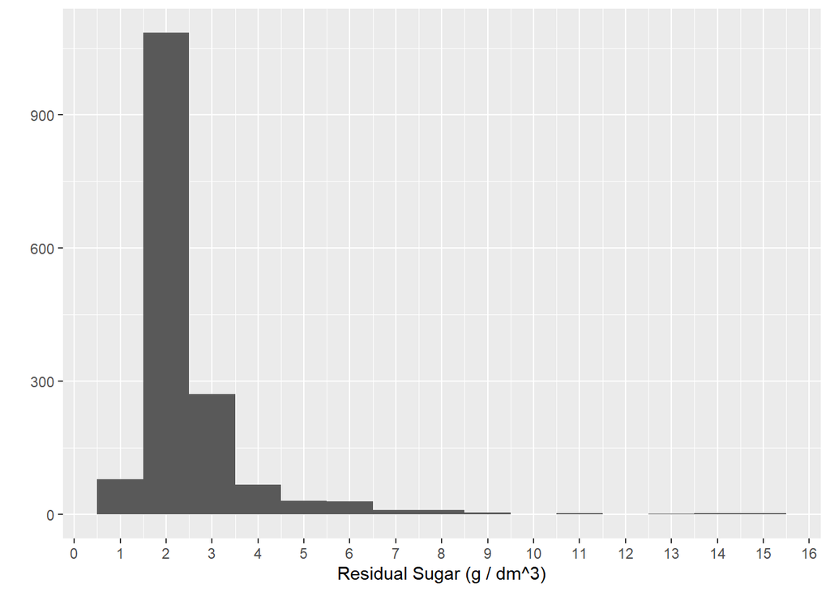

Our residual sugar is positively skewed with most of the data within 1.5-3 g / dm^3. There are some pretty far out numbers going up to around 15.5 g / dm^3. Seeing that most of the residual sugar is in the 1.5-3.5 g/dm^3 is a huge alarm for me. Sugar in wine varies greatly and can be anywhere from 0 to over 200 g/L (g/L is equivalent to g/dm^3) The fact that we only have wines under 20 g/L tells me we are dealing with only dry wines. There should be a relationship with sugar and alcohol content, as wines with more alcohol should have less sugar as sugar is eaten by yeast to make alcohol in wine.

## Density

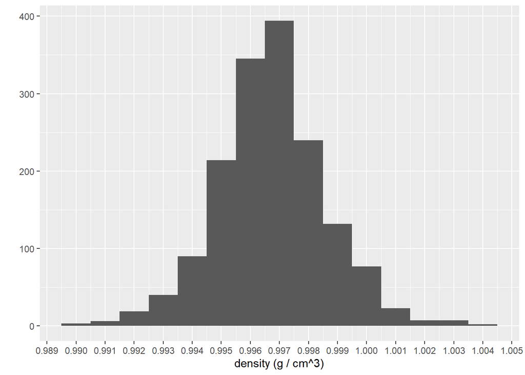

Our density has a nice, normal distribution with most wines falling between .995 and .999 g/cm^3. There should be a relationship between alcohol, sugar and density, as sugar rich wines should be thicker while alcohol rich wines should be thinner.

## Sulphates

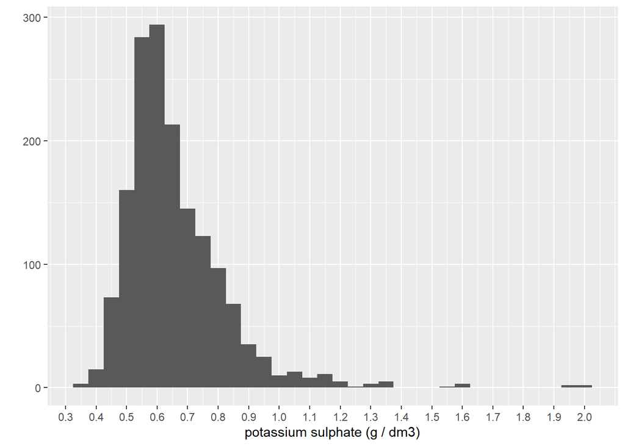

Our sulphates seem to have a fairly normal distribution save for a few outliers. sulphates are used to preserve wine, as our data’s accompanying text file indicates it is an antimicrobial and an antioxidant which leads to sulfur dioxide or sulphites in wine.

## Total and Free Sulfur Dioxide

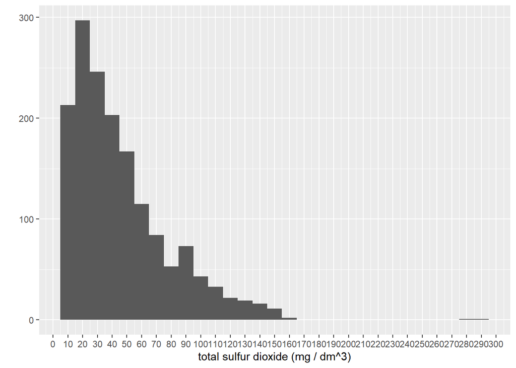

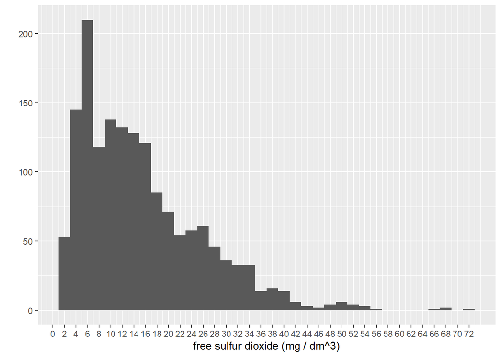

The free sulfur dioxide has a positive skew as does our total sulfur dioxide. Wine makers may be trying to keep these numbers low as sulphites have an undeservedly bad reputation, a topic for another day.

Later on in our analysis I would be interested to see if our wine experts noticed any difference in our sulphate/sulphite rich wine and those that are less so. I expect that we will find that they didn’t spot the difference. We should find that there is an relationship between sulphates/sulphites and alcohol content, as alcohol rich wines should not need as much preservative as those wines with less alcohol.

## Fixed and Volatile Acidity

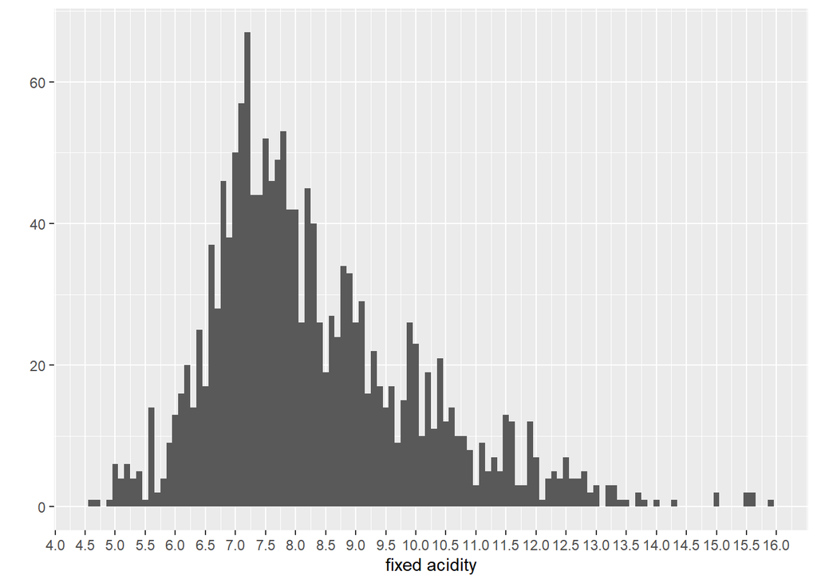

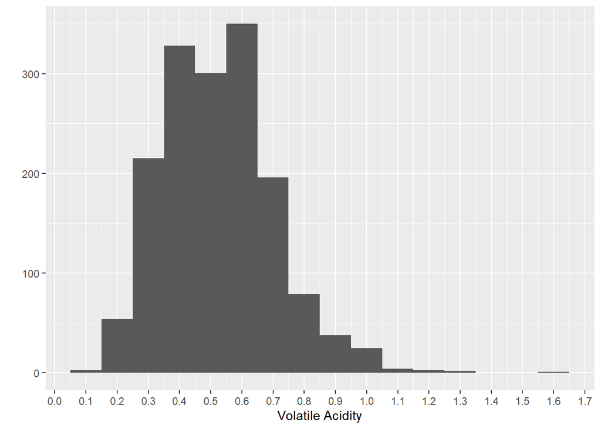

Our volatile acidity also seems to have a fairly normal distribution. It will be interesting to see the relationship between sugar, chloride, acidity, citric acid and quality later on.

## Citric Acid

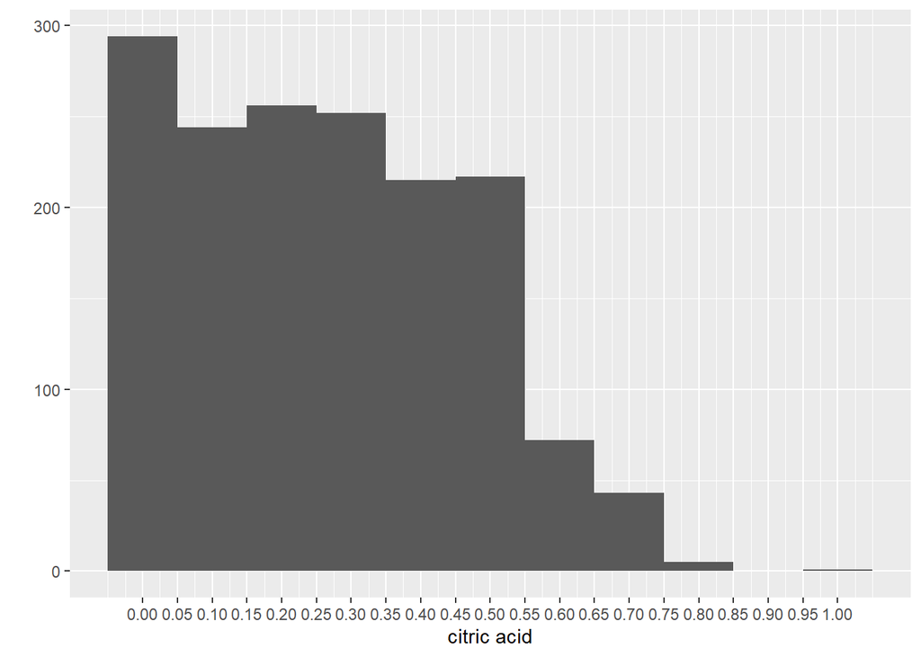

Here we see that our citric acid is pretty evenly distrbuted between 0 and .5. It is interesting that the distribution fell this neatly.

# Univariate Analysis

### What is the structure of your dataset?

Our dataset has 1599 observations with 13 variables all numeric since we converted our integer of quality to numeric to make the data easier to work with

We have a lot of middling quality wines so it makes it more difficult to spot what it was that necessarily put the higher quality wines at that rating. If our data had more very low and very high quality wines vs just a bunch of average wines we might be able to draw more meaningful conclusions than I believe we will find here today.

### What is/are the main feature(s) of interest in your dataset?

- I am interested in what factors put some wines at a higher quality rating than others, particularly if sulphates/sulphites made much of a difference to our experts.
- I am interested in the relationship of alcohol content to preservatives, including acids and sulphates/sulphites.
- There should be a relationship between alcohol and sugar content and density.
- I would like to explore the relationship between volatile acidity and citric acid as I would expect that there volatile acidity would go up with the addition of citric acid.

### Of the features you investigated, were there any unusual distributions?

Did you perform any operations on the data to tidy, adjust, or change the form  
of the data? If so, why did you do this?

I did change wine quality from an integers to a numeric so that it could be graphed on a continuous scale.

As far as unusual distributions, most of our data is either positively skewed or has a relatively normal distribution, suggesting that less is more for wine makers when it comes to any of these factors. Maybe they want to let the flavor of the grapes do the talking instead of making an extreme flavor in any direction.

The residual sugar of the wines is very low. We are dealing with a subset of very dry wines, which seems unusual. —- —-

# Bivariate Plots Section

## Variables to Quality Comparisons

### Sulphates

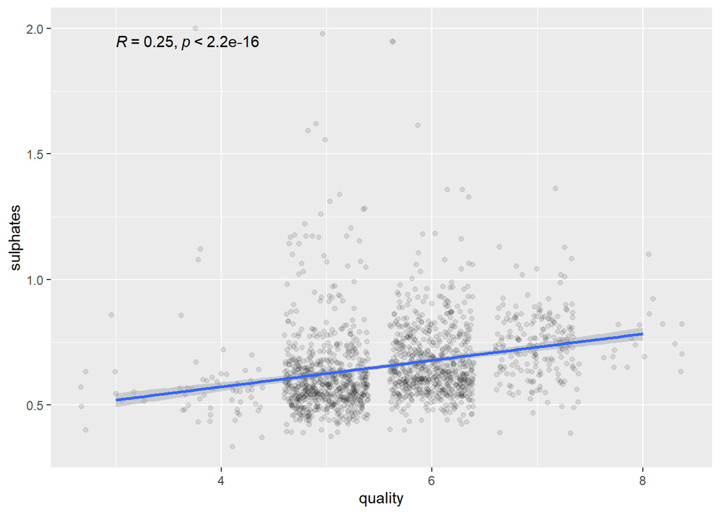

It appears that sulphates in wine do not have a negative effect on quality as I expected, despite some people’s misgivings about the nature of sulphates in food and beverage. In fact, on this plot it appears that the more sulphates were in the wine the higher the rating the flavor of the wine got.

### Total Sulfur Dioxide

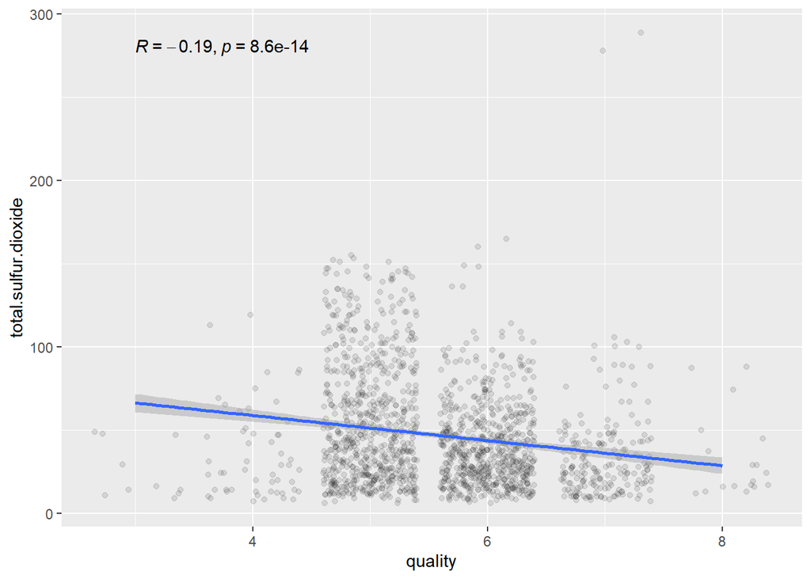

Here we see that the total sulfur dioxide seems to have a weak negative relationship with quality. Indeed, our text file suggests that the more total sulfur dioxide there is, the more prominent their flavor can be, which must be unfavorable

### Free Sulfur Dioxide

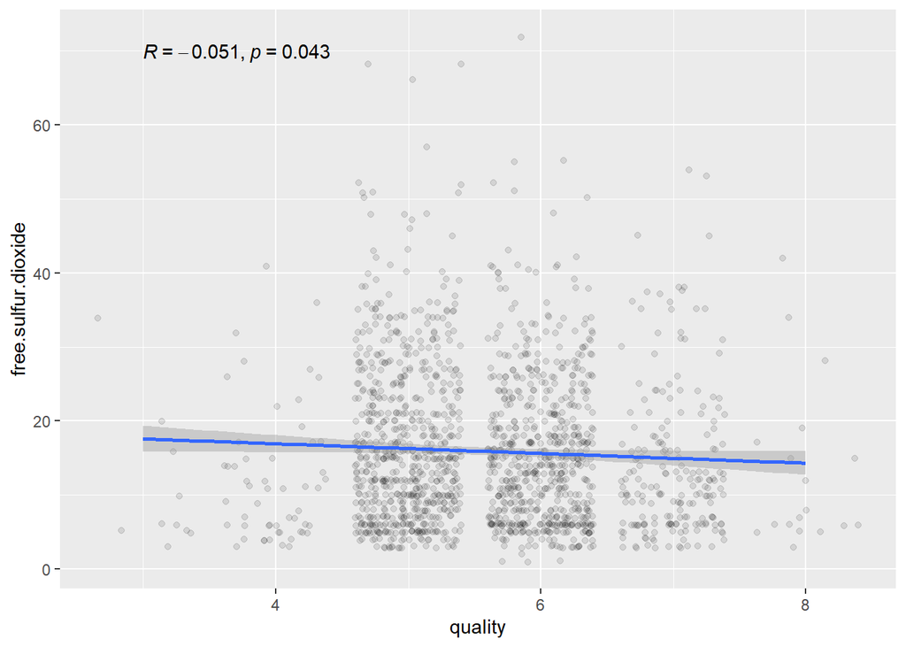

In the free sulfur dioxide and the total sulfur dioxide to quality graphs we see a very weak relationship. There is likely no relationship between free sulfur dioxide content and perceived quality of wine.

### Fixed Acidity

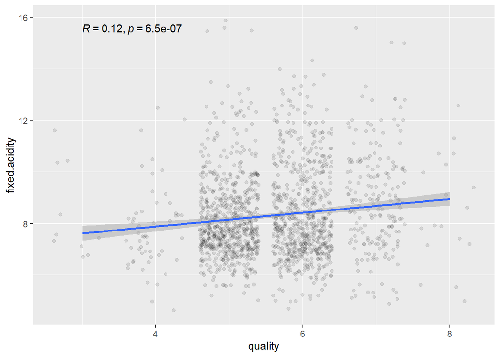

Our fixed acidity appears to have a weak positive relationship with quality.

### Volatile Acidity

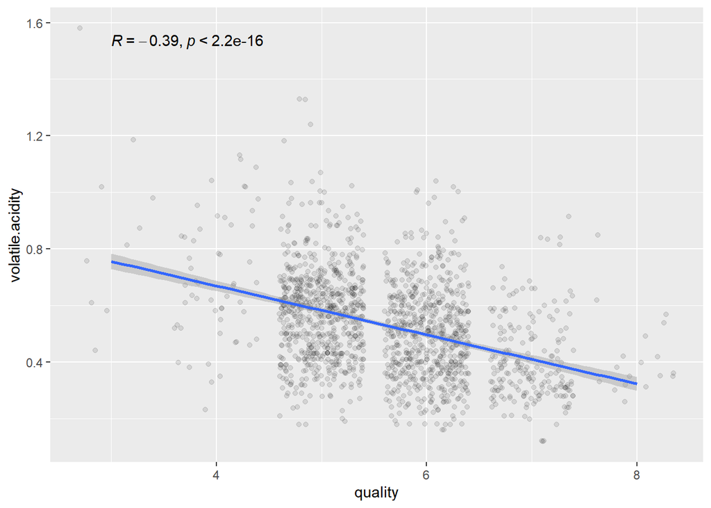

More volatile acidity seems to decrease quality with a borderline weak/moderate relationship.

### Citric Acid

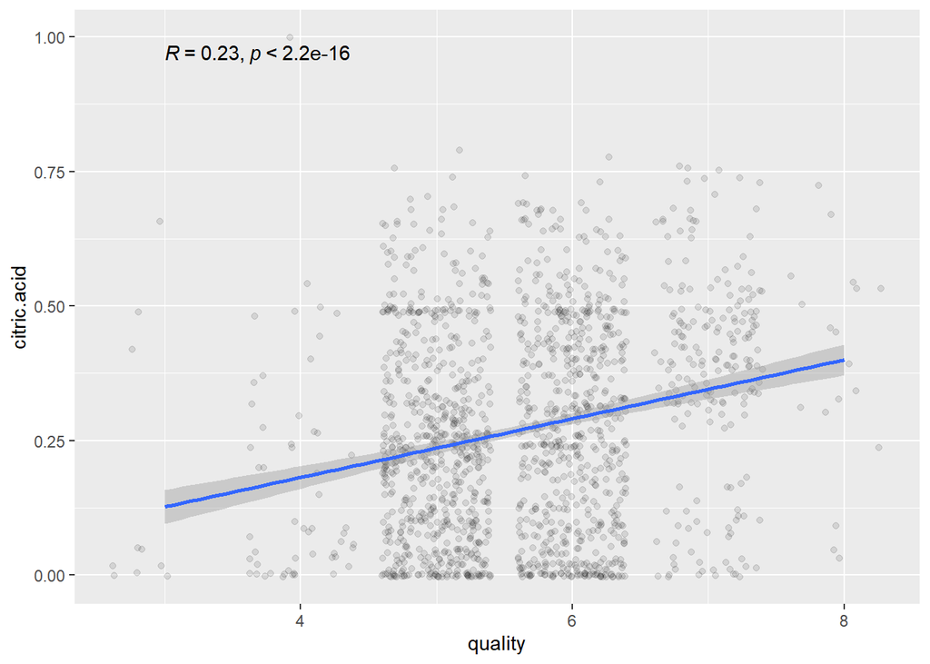

The quality of wine seems to improve with citric acid with a weak relationship.

### Residual Sugar

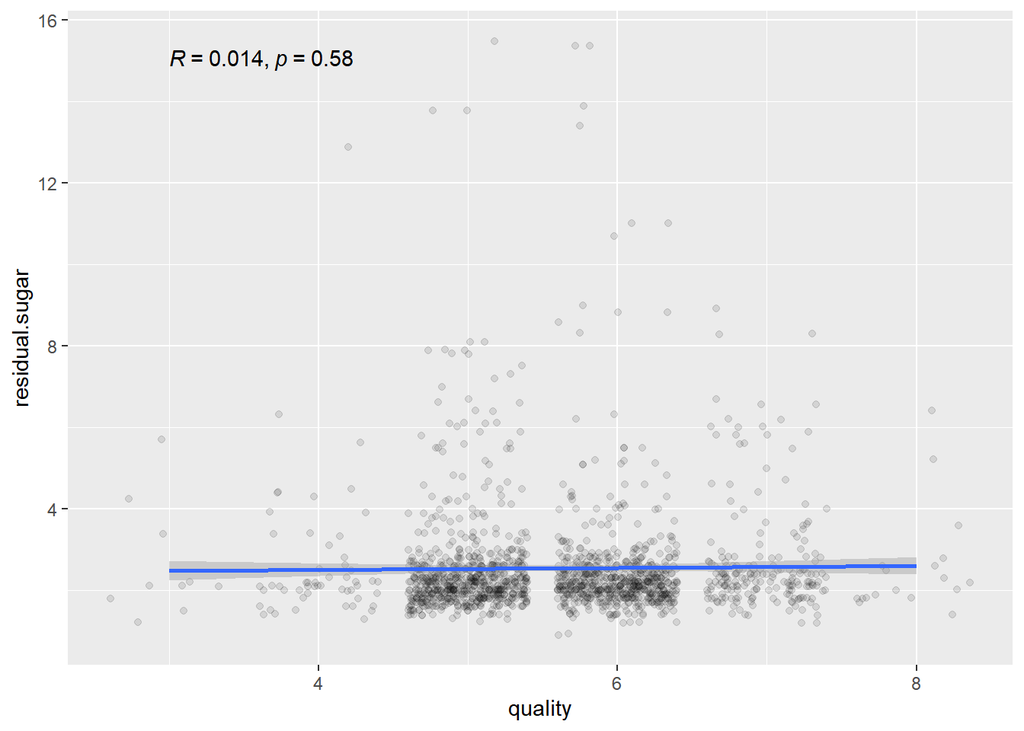

The residual sugar does not seem to have much of an effect on quality. This is likely due to the fact that most of the wines have a very similar amount of residual sugar.

### Chlorides

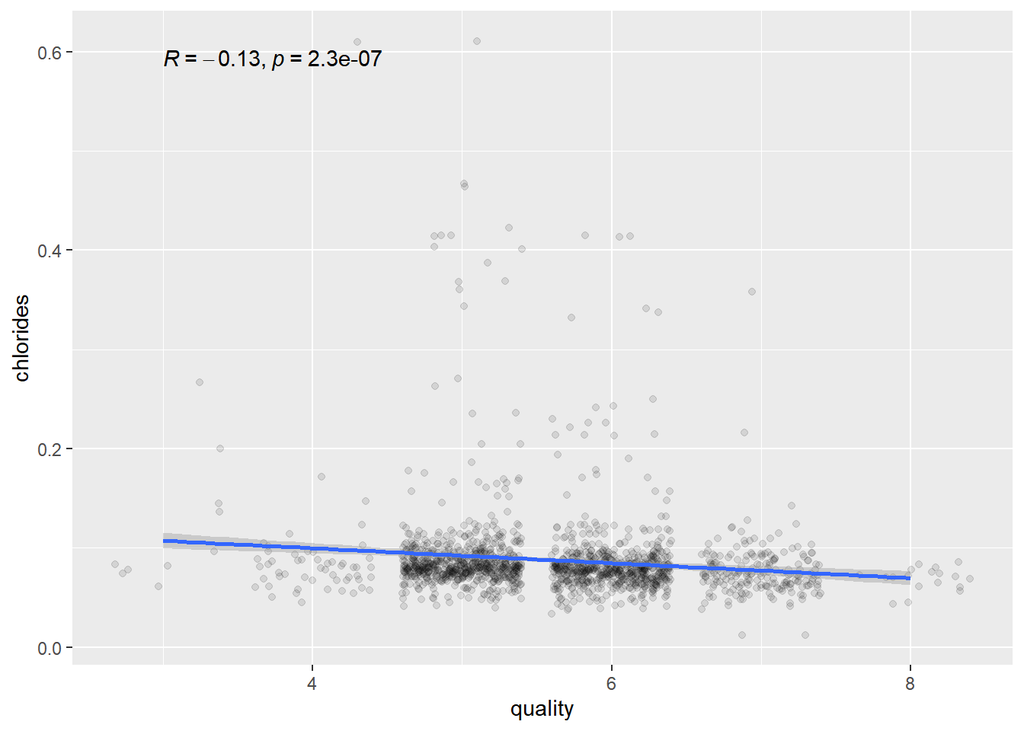

There is a very weak negative correlation with salt/chlorides and quality.

### Density

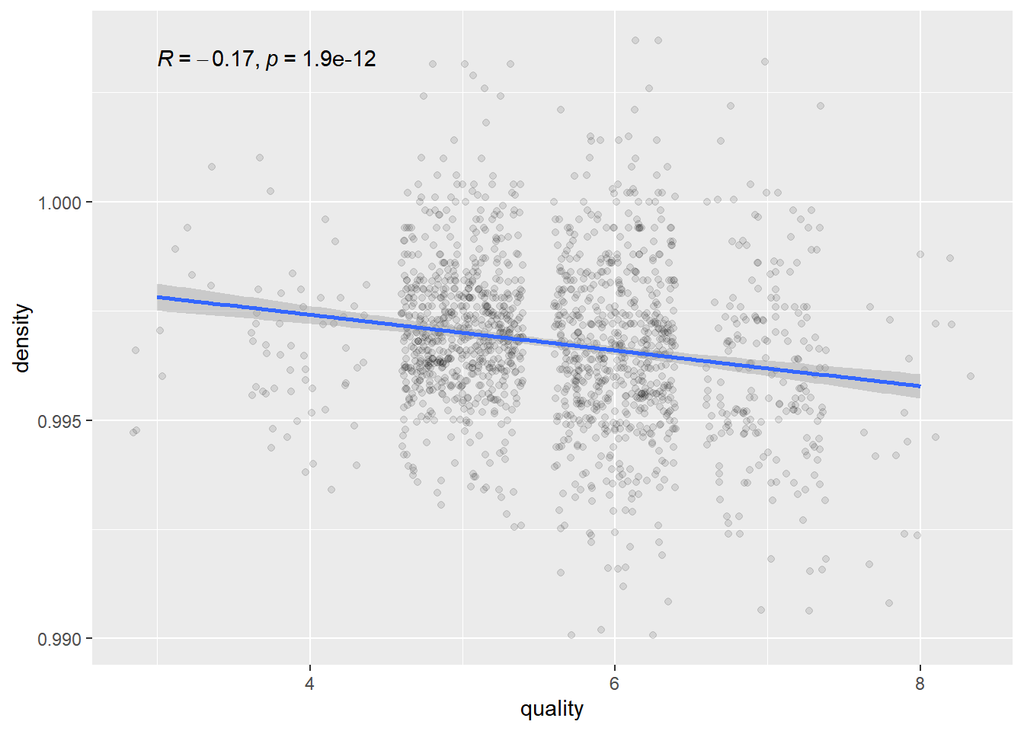

A similarly weak relationship exists between density and quality, with a minor skew toward lower density/more watery wines. Lower density wines should have a higher alcohol content and so it is hard to tell which of these variables cause the preference.

### pH

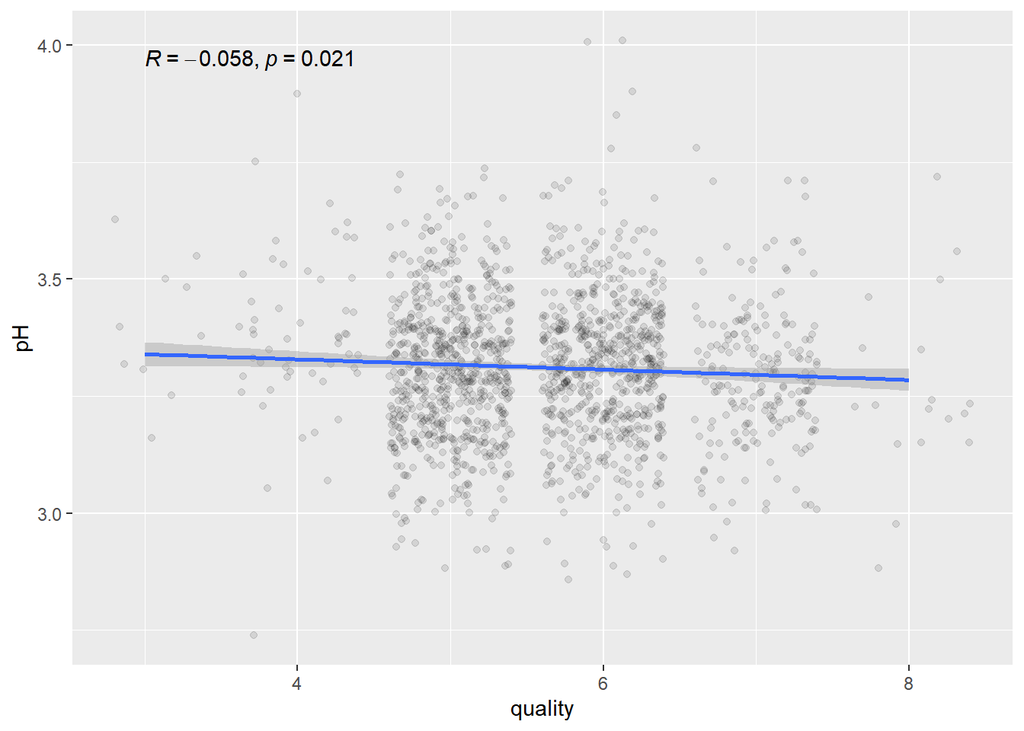

There does not seem to be much of a relationship between quality and pH

### Alcohol

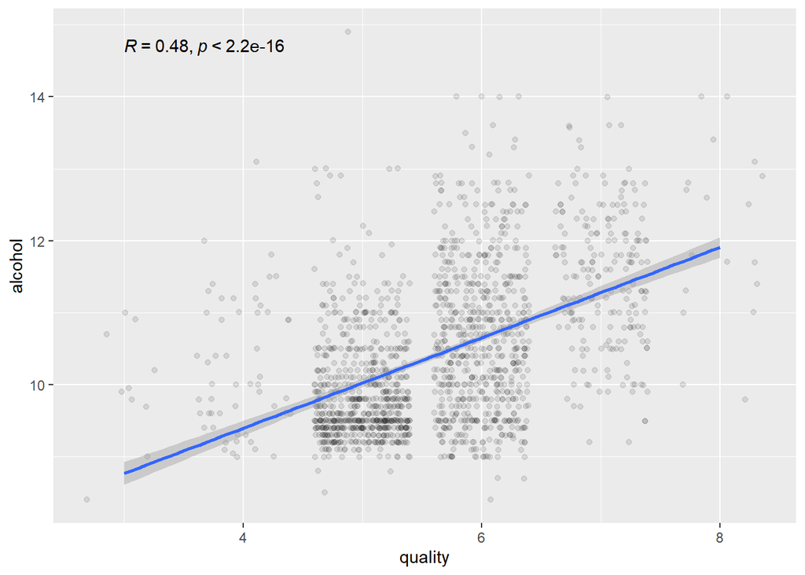

The relationship between alcohol content and quality seems to be stronger than most of the data that we have looked at so far where the more alcohol the higher the quality of the wine. Alcohol leads to dryer flavors in wine and this looks more and more like this tasting was intended to find the best dry wine.

## Residual Sugar to Alcohol

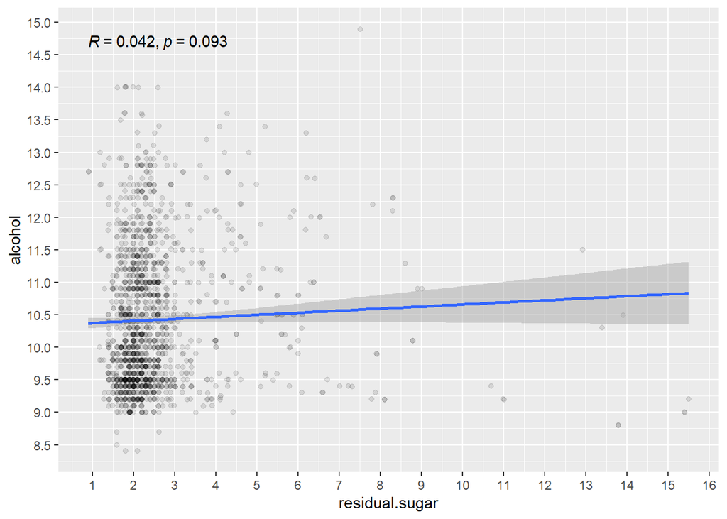

Now this graph is interesting because it does not seem to point to the expected conclusion that the amount of residual sugar would be roughly inversely proportionate to the amount of alcohol in the wine. Between 1.5 and 3 g/dm^3 of sugar the alcohol content varies from less than 8.5% to over 14% by volume. We can see in the outlier range there looks like there is a negative relationship with the alcohol content going down as the residual sugar goes up, but most of the data does not follow our expected trend. Our R value seems to indicate a very weak positive correlation between our variables. This is likely due to the very limited range of sugar in our wines giving us unlikely data.

Let’s zoom in on to the bulk of the data area to see if we see any other trends

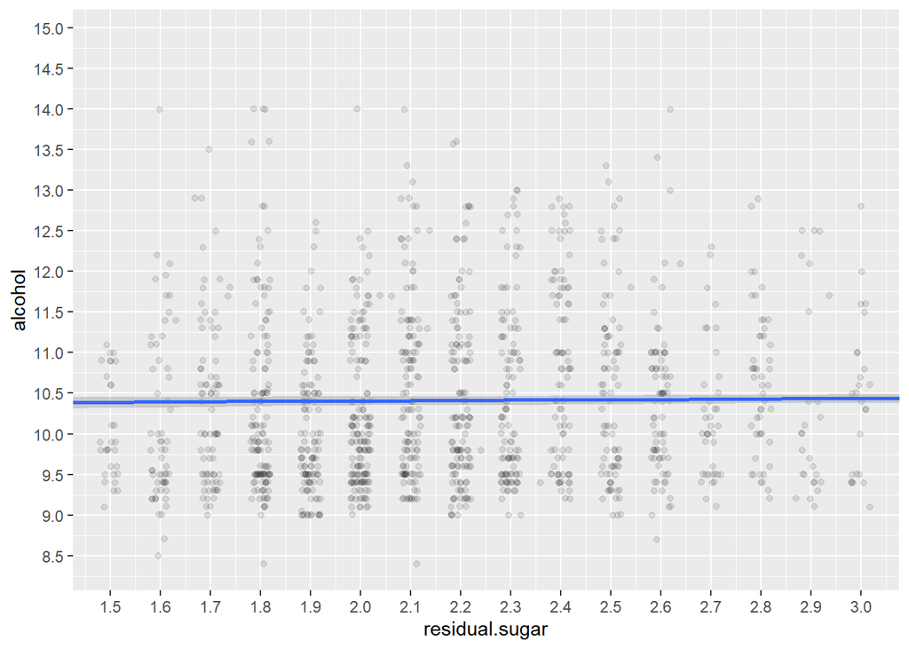

So our graph does not at all show the relationship we are expecting here.

## Alcohol to Preservatives

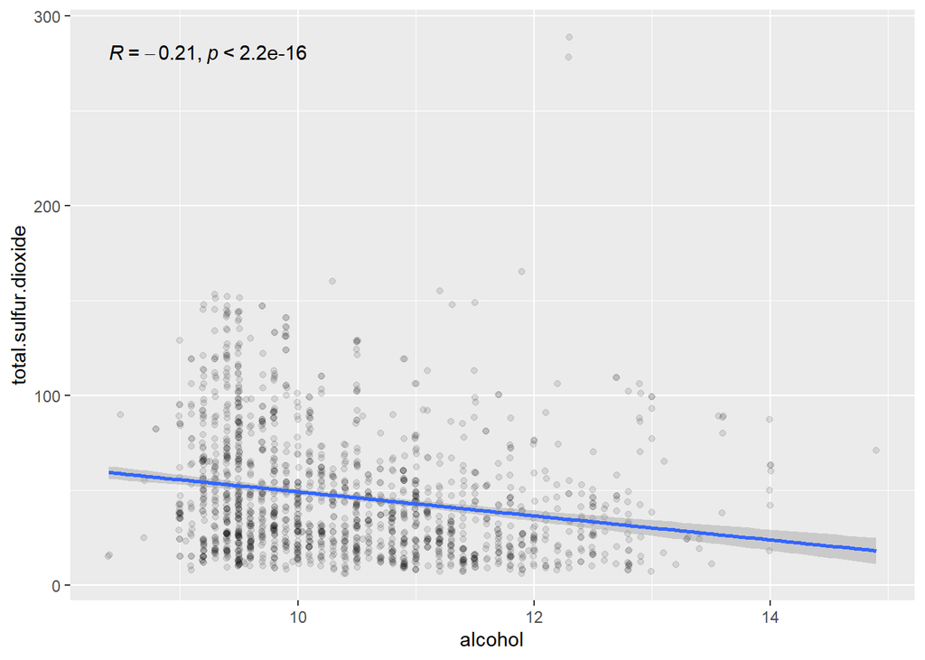

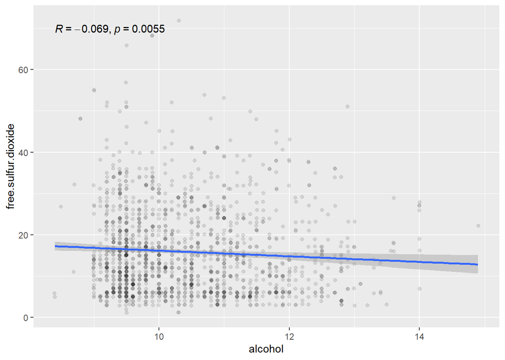

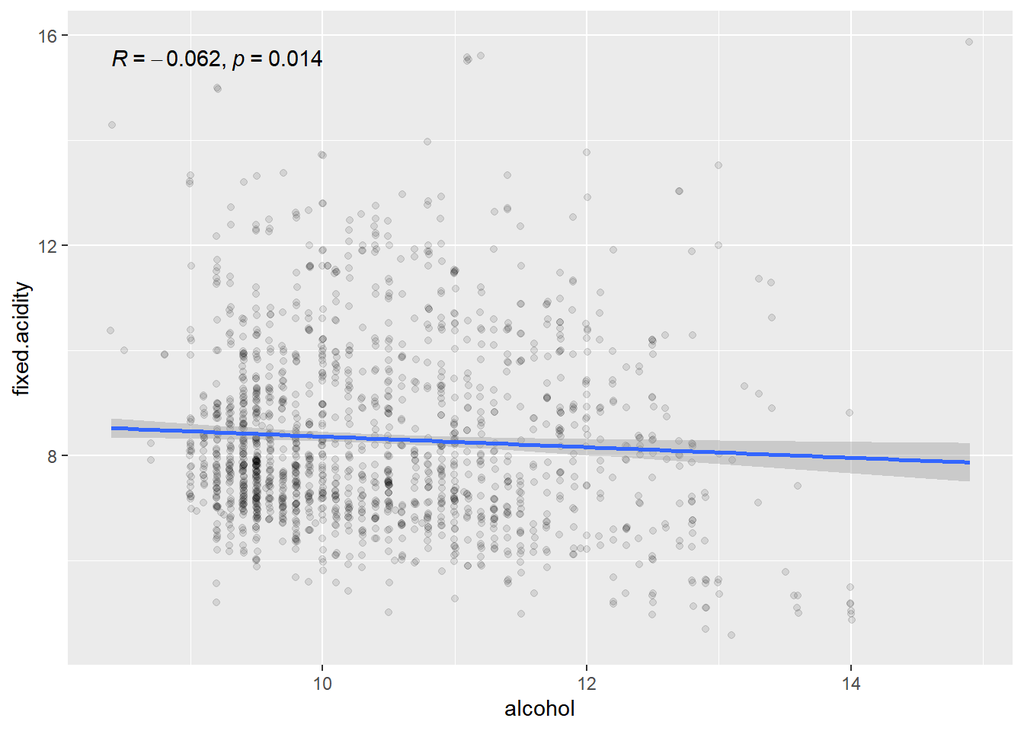

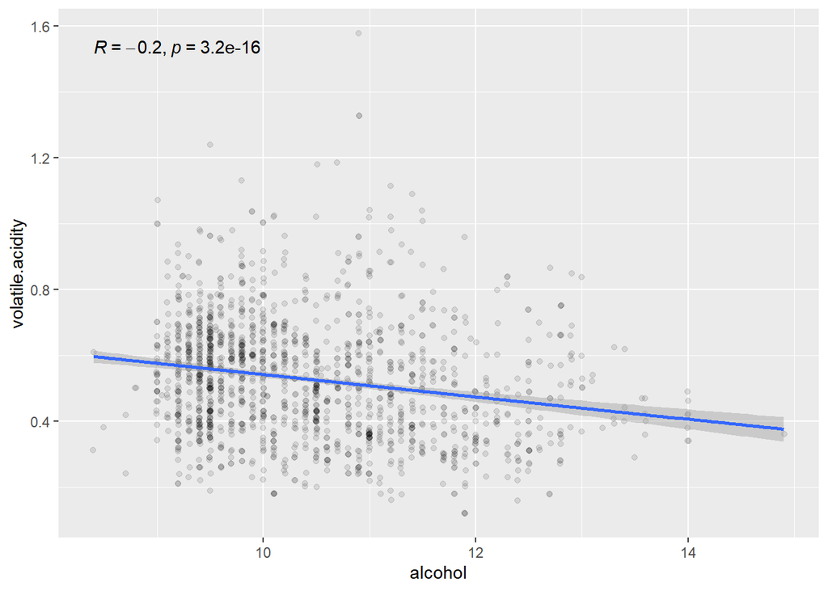

Here, as should be expected, we see that the higher the alcohol content, the lower the preservatives in the wine. The relationship is weak across the board with volatile acidity and total sulfur dioxide having the strongest inverse relationships with alcohol.

## Volatile Acidity to Citric Acid

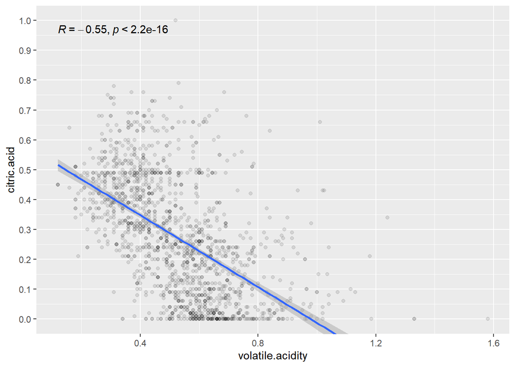

There seems to be a moderate negative correlation with citric acid and volatile acidity. This goes against what I would have thought since citric acid is added after wine is made I would have expected that the volatile acidity would increase with the addition of citric acid.

## Density to Alcohol

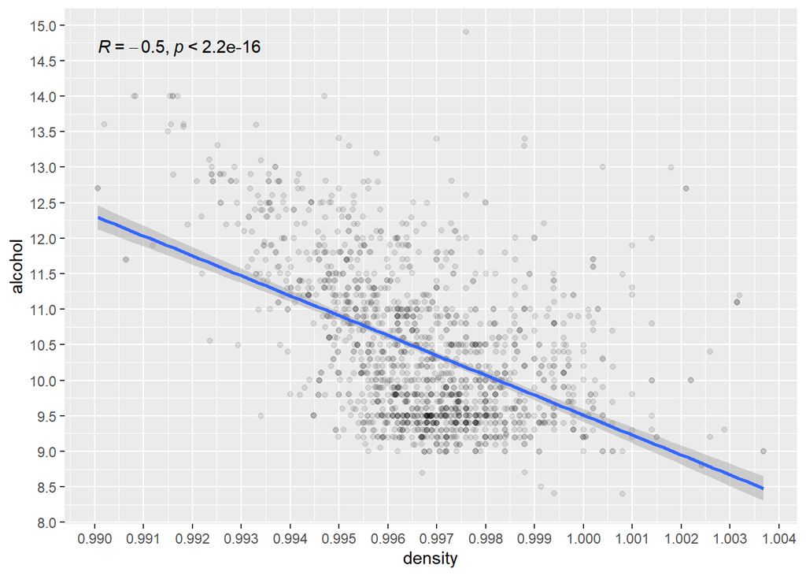

In this graph, as we would expect, the density of the wine goes down as the alcohol content goes up. Oddly, we would expect this because the alcohol is created by yeast eating sugar, so it’s strange with the uniform sugar content that this relationship is maintained.

## Density to Residual Sugar

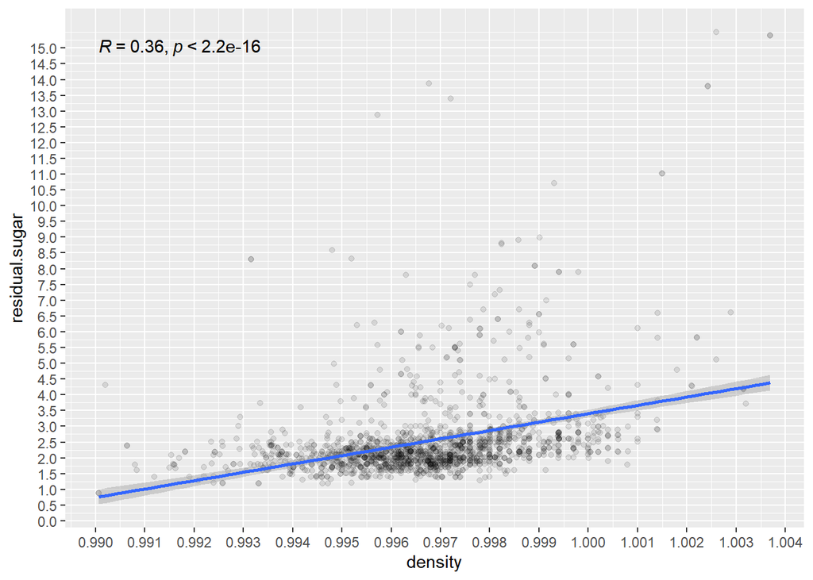

Though the relationship is a bit weaker, we can see that the relationship between density and sugar is maintained where the with should be more dense the more sugar it contains.

# Bivariate Analysis

### Talk about some of the relationships you observed in this part of the

investigation. How did the feature(s) of interest vary with other features in  
the dataset? Did you observe any interesting relationships between the other  
features (not the main feature(s) of interest)? What was the strongest  
relationship you found?

The biggest predictors of wine quality by itself was mostly alcohol. Alcohol had a moderate relationship with wine quality with an r value of .48. Second to that was volatile acidity where it seems that the more volatile acidity there was the less liked was the wine. As explained in our text file, a lot of volatile acide leads to a vinegary taste in wine which many fine abhorrent so this data point makes sense. Citric acid seemed to be well liked with a coefficient of .23. I remember a manager touting that it added a springy, light taste to the wine that people enjoyed and it seems our experts agree to some extent. Our text file indicates something similar that the citric acid adds a ‘freshness’ to wine.

There seemed to be no negative relationship with quality and sulphates in the alcohol, even perhaps, a weak positive correlation, though the more total sulfur dioxide there was the worse of a rating the wine got. The free sulfur dioxide seemed to make little difference in the wine quality.

Our sugar to alcohol relationship should have been inverse, but according to this data there is a very weak relationship. Despite this, the expected relationship of sugar to density and alcohol to density is as we expected with the higher sugar wines being more dense and the higher alcohol wines being less dense.

Our total sulfur dioxide, free sulfur dioxide, fixed acidity and volatile acidity to alcohol comparisons showed a weak negative relationship across the board giving some bit of credence to our hypotheses that the more alcohol a wine had, the less preservatives a wine make might add to it.